# Predicting Plant Exctinctions in South Africa: A Random Forest Approach

Author

Kristen Monaco

Published

April 6, 2024

## Introduction

### What is random forest?

Random Forest is an ensemble learning method that combines multiple decision trees to make predictions. The main idea behind Random Forest is to introduce randomness in the training process by creating a diverse set of decision trees. Each tree in the Random Forest is trained on a random subset of the data and a random subset of features. By combining the predictions of multiple trees, Random Forest reduces the risk of overfitting and improves the overall accuracy and robustness of the model. The randomness in the training process also helps in handling high-dimensional data, handling missing values, and providing estimates of variable importance. Random Forest has gained popularity due to its ability to handle complex datasets and produce reliable predictions in various domains.

## Literature Review

In the paper “Analysis of a Random Forests Model”, Biau [@biau2012analysis] provides an in-depth analysis of the Random Forests model. The author delves into the statistical components and mathematical support, as well as investigates various aspects of the Random Forests, such as its consistency, convergence rates, and the effect of the number of trees on performance. He touches on the importance of variable selection and the increasing adaptability found within the random forest algorithm. Biau provides theoretical insights into the behavior of Random Forests, shedding light on its robustness and effectiveness as a machine learning algorithm.

In “A Random Forest Guided Tour”, Biau and Scornet [@biau2016random] present an extensive exploration of Random Forests, a popular machine learning algorithm. The paper serves as a comprehensive guide, covering aspects of theoretical foundations, methodology, model evaluation, and empirical performance. They discuss the inner workings of Random Forests, including topics such as tree construction, feature selection, and ensemble learning, which aid in predictive analysis. Overall, the paper serves as a valuable resource for those interested in understanding and utilizing Random Forests in their machine learning tasks.

In “Classification and Regression by randomForest,” Liaw and Wiener [@liaw2002classification] discuss the introduction of the randomForest package for classification and regression tasks in the R programming language. An overview of the Random Forest algorithm is provided, including how it draws bootstrap samples and estimates rates of error. This technique is referred to as ensemble learning called bagging and uses decision trees as base learners. Implementation of the randomForest package addresses parameters for tuning the model and handling missing values. It is noted that the production of multiple trees is crucial in obtaining variable importance and measures of proximity. Overall, the paper serves as a practical guide for R users and highlights the advantages of using random forests for both classification and regression problems, such as robustness to overfitting and high prediction accuracy.

In the paper “Random Forest as a Predictive Analytics Alternative to Regression in Institutional Research”, the authors [@lingjun2019random] explore the application of Random Forests as a predictive analytics tool in institutional research. They discuss the limitations of traditional regression models in handling complex datasets and introduce Random Forest as an alternative approach. To do this, they highlight the key benefits of the Random Forest model, as it has the ability to handle non-linear relationships, interactions, and high-dimensional data effectively. In addition, they expound upon predictive capabilities, improved accuracy, and robustness as a strategy for data-based decision making.

In “Machine Learning Benchmarks and Random Forest Regression”, Segal [@segal2004machine] explores the application and effectiveness of Random Forest Regression in the context of machine learning. Machine learning algorithms may face challenges, which emphasize the need for standardized datasets and evaluation metrics. Segal (2004) examines how Random Forest Regression performs across various datasets, comparing its performance to other regression techniques. The study highlights the strengths of Random Forest Regression in handling non-linear relationships and noisy data, showcasing its versatility and robustness. Additionally, the paper provides insights into the impact of different parameters on the performance of Random Forest Regression, offering practical guidance for its implementation. Overall, the paper contributes to the understanding of Random Forest Regression and its potential as a powerful tool in the field of machine learning.

## Methods

### Decision Trees

Decision Trees are a type of Supervised Machine Learning where the data is continuously split according to a certain parameter. The tree can be explained by two entities: decision (internal) nodes and leaves. The decision nodes are where the data is split, and the leaves are the decisions or the final outcomes.

A decision tree is a flowchart-like structure in which each internal node represents a test on a feature (e.g. whether a coin flip comes up heads or tails) , each leaf node represents a class label (decision taken after computing all features), and branches represent conjunctions of features that lead to those class labels. The paths from root to leaf represent classification rules. The algorithm for predicting the class of a given dataset starts from the root node of the tree. It compares the values of the root attribute with the record attribute, follows the branch based on the comparison, and jumps to the next node. This process continues until it reaches the leaf node of the tree.

Decision trees in random forest work together to create a robust and accurate model by leveraging the diversity and averaging multiple decision trees.

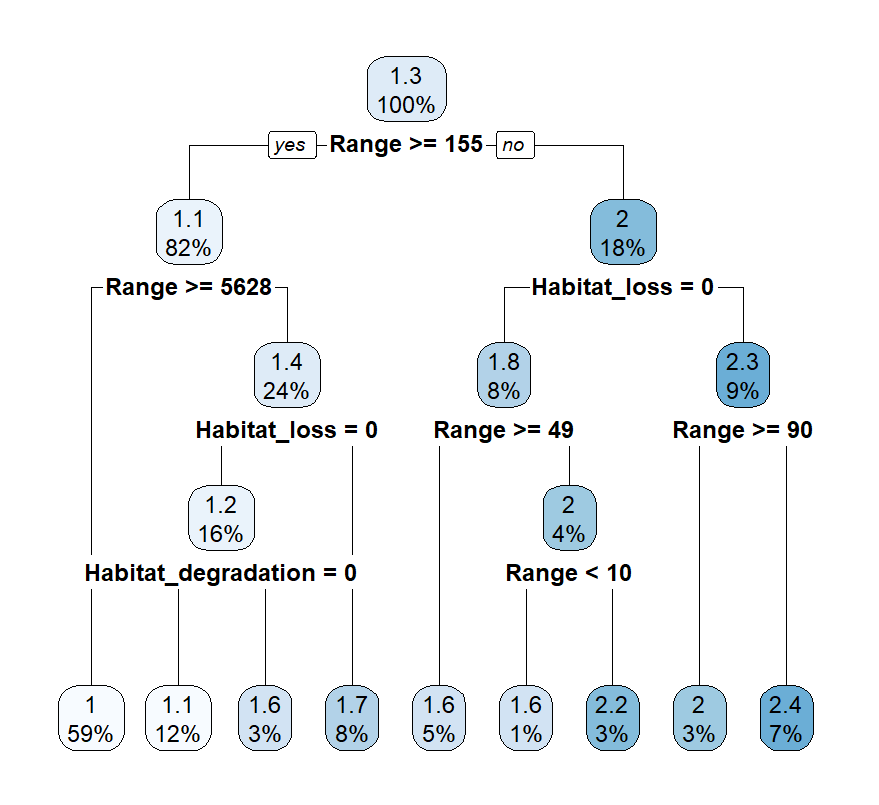

When evaluating the quality of the splits in decision trees, several metrics are considered.

**1. Gini impurity:**

The Gini coefficient is a measure of inequality between 0 and 1, where a value closer to 1 indicates more inequality. This is used to calculate inequality in income and wealth, but it can be used in other problems where a measure of inequality is needed.
$$G = \frac{\sum_{i=1}^{n}\sum_{j=1}^{n}|x_i - x_j|}{2n^2\bar{x}}$$

**2. Entropy:**

For decision trees, a related measure is used to measure the entropy of a result by calculating the probability that a random entry will be in the wrong class if it were randomly assigned a label.
$$H=\sum\limits_{i=1}^{n}-p_i log_2 p_i$$

**3. Information gain:**

This measure can be used in multiclass problems and is often used for finding where to split the features. The other commonly used option is Entropy, which is also an entropy measure but with a more complex calculation.

The tradeoff is a faster calculation using the Gini impurity, with a possibly higher accuracy.
$$I_G=1-\sum\limits_{i=1}^{J}p_i^2$$

**4. Out of bag error estimation:**

- Each decision tree is trained on a bootstrapped sample of the original dataset.
- The data points that are not included in the bootstrapped sample for a particular tree are called out-of-bag instances.
- OOB error provides a measure of how well the random forest model is likely to perform on new data.
- It is useful for assessing model performance and tuning hyperparameters.

$$\text{OOB Error} = \frac{1}{N} \sum_{i=1}^{N} I(y_i \neq \hat{y}_{i, \text{OOB}})$$

### Random Forest involves the following basic concepts:

1. **Bootstrap Sampling (Bagging):** Perform random sampling with replacement on the original dataset to form a new dataset for training a decision tree. In each round of bootstrap sampling, about 36.8% of the samples will be missed, not appearing in the new dataset, and these data are referred to as out-of-bag (OOB) data.
2. **Random Feature Selection:** At each node of the decision tree training, randomly select a subset of features, and then use information gain (or other criteria) to choose the best split. Repeat the above steps, generating multiple decision trees, to form a “forest”.
3. **Prediction:** When predicting new data samples, each tree produces its own prediction result. Random Forest synthesizes these results and uses majority voting to determine the final prediction outcome.
4. **Ensemble Learning via Hard Voting Classifier:** By voting, the results of five models are integrated to get the combined outcome. The result selects the category that appears most frequently as the final prediction result. This is a strategy of ensemble learning, known as the Hard Voting Classifier. For a sample point x, five models make predictions respectively:

> y1 = Model1(x)

> y2 = Model2(x)

> y3 = Model3(x)

> y4 = Model4(x)

> y5 = Model5(x)

Put these five prediction results into a set `Y = {y1, y2, y3, y4, y5}`, and the final prediction result y_final is the element that appears most frequently in the set Y, mathematically represented as:

> y_final = mode(Y)

### Five normalization methods

The data needs to be normalized using 5 different methods (**Min-Max Normalization**, **Z-Score Normalization**, **Max Absolute Scaling**, **L1 Norm Normalization**, **L2 Norm Normalization**) due to significant differences in feature values initially.

> X_new = (X_old-min(X_old)) / (max(X_old)-min(X_old))

> X_new = (X_old - mean(X_old)) / sd(X_old)

> X_new = X_old / max(abs(X_old))

> X_new = X_old / sum(abs(X_old))

> X_new = X_old / sqrt(sum(X_old^2))

### Evaluation

- Accuracy = sum(actual labels == predicted labels) / total number of labels
- Recall = True Positives / (True Positives + False Negatives)
- Precision = True Positives / (True Positives + False Positives)
- F1 = 2 * (Precision * Recall) / (Precision + Recall)

### Final outcome:

> y1 = Model1(x)

> y2 = Model2(x)

> y3 = Model3(x)

> y4 = Model4(x)

> y5 = Model5(x)

Place these five prediction results into a set `Y = {y1, y2, y3, y4, y5}`. The final prediction result `y_final` is the element that appears most frequently in the set `Y`, mathematically represented as `y_final = mode(Y)`.

## Benefits/Advantages

- Capable of performing both classification and regression tasks.
- Capable of handling large datasets with high dimensionality.
- Decreased training time compared to other algorithms.
- Promotes predictive ability with high accuracy, even with large datasets.
- Can solve problems internally and still maintain accuracy, even when a large proportion of data is missing.
- Enhances the accuracy of the model and prevents issues in overfitting.
- Can be used as a feature selection tool using its variable importance plot.

## Limitations/Challenges

- Prone to problems, such as bias and overfitting.
  - However, when multiple decision trees form an ensemble in the random forest algorithm, they predict results with greater accuracy, particularly when the individual trees are uncorrelated with each other.
- Time-consuming.
  - Since random forest algorithms can handle large data sets, they can provide more accurate predictions. However, the process can be slow as they are computing data for each individual decision tree.
- Requires more resources.
- More complex.
  - The prediction of a single decision tree is easier to interpret when compared to a forest of them.

## Assumptions

- Independence of trees: Each tree is built using a random subset of features and a bootstrapped sample of the data, aiming to reduce correlation between trees.
- Randomness: While some of the actual values in the feature variable of the dataset should be present so the classifier can predict accurate results, random forests must also assume random subset of features to prevent overfitting and encourage diversity.

# Analysis and Results

## Data and Visualization

Data Source: **Mendeley Data**

[Species data used in Random Forest modelling to determine predictors of extinction](https://data.mendeley.com/datasets/tc6syk8vwf/1)

**Description**

Data was extracted from the South African Red List (South African National Biodiversity Institute 2021) database to compile a profile for plant extinctions. South Africa offers a wide array of biodiversity and estimates over 22,000 plant taxa. The International Union for Conservation of Nature’s (IUCN) (International Union for Conservation of Nature 2023) Red List of Threatened Species provides a standardized method to document and assess extinctions (IUCN 2023). Species are classified into one of the following groups: Extinct (EX), Extinct in the wild (EW), Critically endangered possibly extinct (CR PE), Critically endangered (CR), Endangered (EN), Vulnerable (VU), Near threatened (NT), Conservation dependent (CD), Least concern (LC), and Data deficient (DD).

Plants are an essential component to an ecosystem’s functionality, so it is critical to evaluate drivers of extinction and determine methods of prevention. To examine potential indicators for extinctions, extinct, threatened, and non-threatened taxa are compared to identify and/or distinguish traits that may be associated with risk or vulnerability. The final dataset comprises 842 extant taxa, 33 Extinct taxa, and 69 Possibly Extinct (CR PE) taxa, to total 944 species.

The table (Colff et al. 2023) below organizes and summarizes the explanatory variables.

[output not shown]

```r
library(caret)
library(caTools)
library(dplyr)
library(dslabs)
library(ggcorrplot)
library(ggthemes)
library(ggplot2)
library(gridExtra)
library(gsheet)
library(gtsummary)
library(ipred)
library(knitr)
library(lessR)
library(plyr)
library(randomForest)
library(readr)
library(ROSE)
library(rpart)
library(rpart.plot)
library(rsample)
library(splitTools)
library(tidyverse)
library(vip)
library(visreg)

data2 <- as_tibble(gsheet2tbl("https://docs.google.com/spreadsheets/d/1BJui4r7xoVY6e3z2-IgCr_eBn7SvNAQ4BEpPo1GILNU/edit?usp=sharing"))

data2 <- as.data.frame(data2)
set.seed(123)
split2 <- sample.split(data2, SplitRatio = 0.7)
species_train <- subset(data2, split2 == "TRUE")
species_test <- subset(data2, split2 == "FALSE")
#m3 <- rpart(
#  formula = Group~ LF + GF + Biomes + Range +
#    Habitat_degradation + Habitat_loss + IAS +
#    Other + Unknown + Other + Over_exploitation,
#  data    = species_train,
#  method  = "anova"
#)
```

# Statistical Modeling

## Packages

The R packages utilized for running the statistical modeling for the Random Forest algorithm were **readr**, **plyr**, **ipred**, **caret**, **caTools**, **randomForest**, **ROSE**. - readr: Part of the tidyverse, readr is designed for reading rectangular data, particularly CSVs (comma-separated values) and other delimited types of text files. It’s known for its speed and for providing more informative error messages compared to base R functions like read.csv. It also converts data into tibbles, which are a modern take on data frames.

- **plyr**: This package is used for splitting, applying, and combining data. plyr is known for its capability to handle different data types (arrays, lists, data frames, etc.) and apply functions to each element of the split data, then combine the results. Note that plyr is largely superseded by dplyr (also part of tidyverse), which is more efficient especially for large datasets.
- **ipred**: Standing for “Improved Predictors”, ipred provides functions for predictive modeling. It includes methods for bagging (Bootstrap Aggregating), which helps improve the stability and accuracy of machine learning algorithms, particularly for decision trees.
- **caret**: The caret package (short for Classification And REgression Training) is a comprehensive framework for building machine learning models in R. It simplifies the process of model training, tuning, and predicting by providing a unified interface for various machine learning algorithms.
- **caTools**: This package contains several tools for handling data, including functions for reading/writing Binary Large Objects (BLOBs), moving window statistics, and splitting data into training/testing sets. It’s often used for its simple and effective method for creating reproducible train/test splits.
- **randomForest**: As the name suggests, this package is used for implementing the Random Forest algorithm for classification and regression tasks. Random Forest is an ensemble learning method that operates by constructing a multitude of decision trees and outputting the mode of the classes (classification) or mean prediction (regression) of the individual trees.
- **ROSE**: Standing for Random OverSampling Examples, the ROSE package is used to deal with imbalanced datasets in binary classification problems. It generates synthetic samples in a two-class problem to balance the class distribution, using smoothed bootstrapping. This helps improve the performance of classification models on imbalanced datasets.

## Data Preparation

### Original Dataset Preview

```r
kable(head(data2, 10))
```

| LF | GF | Biomes | Status | Range | Habitat_degradation | Habitat_loss | IAS | Other | Over_exploitation | Pollution | Unknown | Group |
| --- | --- | --- | --- | --- | --- | --- | --- | --- | --- | --- | --- | --- |
| Perennial | Parasitic | Generalist | LC | 188 | Yes | Yes | Yes | No | No | No | No | NotThr |
| Perennial | Tree | Generalist | EN | 6899 | Yes | Yes | Yes | Yes | No | No | No | Thr |
| Perennial | Suffrutex | Succulent Karoo | LC | 46341 | No | No | No | No | No | No | No | NotThr |
| Annual | Herb | Generalist | LC | 465969 | No | No | No | No | No | No | No | NotThr |
| Perennial | Lithophyte | Fynbos | VU | 50 | No | No | No | No | No | No | No | Thr |
| Perennial | Herb | Generalist | LC | 414160 | Yes | Yes | Yes | No | No | Yes | No | NotThr |
| Annual | Herb | Generalist | LC | 15526 | No | Yes | No | No | No | No | No | NotThr |
| Annual | Herb | Succulent Karoo | LC | 11948 | No | No | No | No | No | No | No | NotThr |
| Annual | Herb | Fynbos | LC | 35478 | Yes | Yes | Yes | No | No | No | No | NotThr |
| Perennial | Shrub | Generalist | LC | 393214 | No | No | No | No | No | No | No | NotThr |

Given a minority class sample point x, we find its k nearest neighbors. Then, we randomly select one of these neighbors, denoted as z, and construct a new data point y that lies on the line segment between x and z:

> y = x + λ * (z - x)

Here, λ is a random number between 0 and 1.

#### Tuning

An approach which considers hyperparameters and involves tuning the number of candidate variables to select from at each split. However, there are a few additional hyperparameters that we should be aware of. Although the argument names may differ across packages, these hyperparameters should be present:

- ntree: number of trees
  - We want enough trees to stabilize the error.
- mtry: number of variables to randomly sample as candidates at each split
  - When mtry = *p*, this is similar to bagging.
  - When mtry = 1, the split variable is random.
  - A common suggestion is to start with 5 values evenly spaced across the range from 2 to *p*.
- sampsize: number of samples
- nodesize: minimum number of samples within the terminal nodes
  - Controls complexity
- maxnodes: maximum number of terminal nodes
  - More nodes results in deeper, more complex trees, while fewer nodes produce shallower trees.

## Conclusion

Random Forest is a powerful and flexible machine learning algorithm that can be used for a wide range of tasks. It is particularly useful when dealing with complex data composed of a large number of features and when the goal is to achieve high predictive accuracy while avoiding overfitting. The algorithm incorporates versatility in its capabilities for classification and regression tasks, handling missing data, and displaying robustness when faced with outliers and noisy data.

## References

Colff, Dewidine van der, Sabrina Kumschick, Wendy Foden, Domitilla Raimondo, Christophe BOTELLA, Lize von Staden, and John Wilson. 2023. “Species Data Used in Random Forest Modelling to Determine Predictors of Extinction.” Mendeley Data. https://doi.org/10.17632/tc6syk8vwf.1.

International Union for Conservation of Nature. 2023. “The IUCN Red List of Threatened Species. Version 2023-1.” https://www.iucnredlist.org.

South African National Biodiversity Institute. 2021. “Red List of South African Plants Version 2021.1.” http://redlist.sanbi.org/stats.php.